# STAT 8111 LECTURE NOTE 4

Jingxiang Li

09/08/2014

## The Bayes Risk of $\delta$ agianst $\pi$

**Def.** $\pi(\theta)$ is a probability distribution in $\Theta$

**Def.** $\Pi(\delta, \pi) = \int_{\Theta}{R(\theta, \delta)\pi(\theta)d\theta}$

**Def.** $\delta^{*}$ is the best Bayes Decision Function against $\pi$ if $\Pi(\delta^{*}, \pi) = \inf_{\delta \in \bar{D}}\Pi(\delta, \pi)$

**e.g.** We buy Strawberry, $\Theta = \{A, NA\}$, where $A$ means the Strawberry is acceptable, and $NA$ means unacceptable; $D = \{d_{0}, d_{1}, d_{2}\}$, where $d_{i}$ means we buy $i$ quart of strawberry. We have Loss Function L as follows:

| $d$ | $L(A, d_{i})$ | $L(NA, d_{i})$ |
| --- | --- | --- |
| $d_{0}$ | $1/2$ | $1/2$ |
| $d_{1}$ | $1/4$ | $2/3$ |
| $d_{2}$ | $0$ | $1$ |

Notice that this is a *No Data Problem*, whenever you think about Bayes, you should first think about the *No Data Problem*.

$\Pi(d_{0}, \pi) = \frac{1}{2}\pi + \frac{1}{2}(1 - \pi) = \frac{1}{2}$

$\Pi(d_{1}, \pi) = \frac{2}{3}\pi + \frac{1}{4}(1 - \pi) = \frac{1}{4} + \frac{5}{12}\pi$

$\Pi(d_{2}, \pi) = \pi$

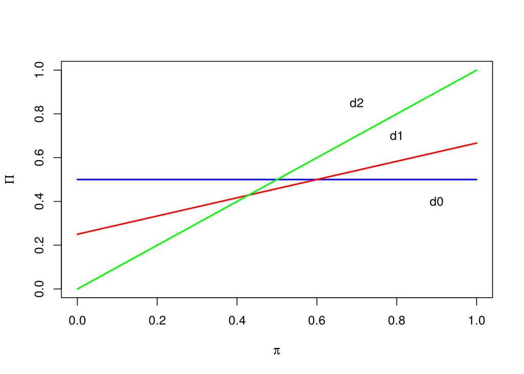

Let X equals to your feeling when you taste a strawberry

$\begin{aligned} P_{NA}(X = x) = & \frac{7}{12},~~x=1~~~~\\ & \frac{4}{12},~~x=2~~~~\\ & \frac{1}{12},~~x=3~~~~ \end{aligned}$ $\begin{aligned} P_{A}(X = x) = & \frac{1}{12},~~x=1\\ & \frac{3}{12},~~x=2\\ & \frac{8}{12},~~x=3 \end{aligned}$

for each $\delta$, we have $\begin{aligned} R(A, \delta) & = \sum_{x}L(A, \delta(x))P_{A}(X = x)\\ R(NA, \delta) & = \sum_{x}L(NA, \delta(x))P_{NA}(X = x) \end{aligned}$

$\delta \rightarrow (R(A, \delta), R(NA, \delta))$ $\Pi(\delta, \pi) = (1 - \pi)R(A, \delta) + \pi R(NA, \delta)$

We map $\delta$ to points in a 2-dimensional space, and we try to find $\delta$ with minimum Bayes Risk. if $\delta$ is randomized, then the set of $\delta$ is a convex set, and thus it’s a simple Linear Programming in this strawberry problem.

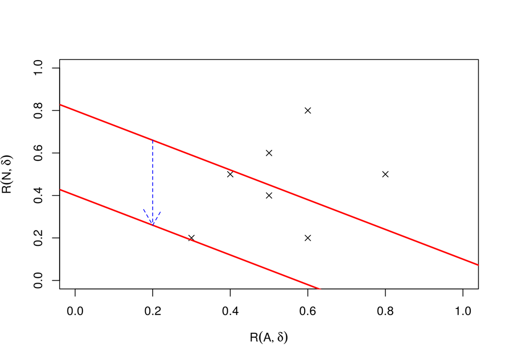

## ————————————————————-

Now we have $X$, $D$, $L(\theta, d)$, $\bar{D}$, $\bar{\bar{D}}$, $\Theta = \{\theta_{1},...,\theta_{k}\}$, $0 \leq R(\theta, m) < \infty, \forall m \in \bar{\bar{D}}$

**Def.** $S = \{(y_{1},...,y_{k}): y_{j} = R(\theta_{j}, m)$ for $j = 1,...,k,$ for some $m \in \bar{\bar{D}}\}$, We call $S$ a *Risk Set*

**Lemma** $S$ is a convex subset of $\mathbb{R}^{k}$

**Proof** Suppose $y \in S$ and $y' \in S$, $y$ comes from $m \in \bar{\bar{D}}$, $y'$ comes from $m' \in \bar{\bar{D}}$, and for $\alpha \in [0, 1]$, $\alpha m + (1 - \alpha)m' \in \bar{\bar{D}}$

$S_{\Delta} = \{ (y_{1},...,y_{k}): y_{j} = R(\theta_{j}, \delta)$ for $j = 1,...,k,$ for some $\delta \in \bar{D}\}$

$S$ is convex and is the smallest convex set which contains $S_{\Delta}$, Since we assume that two types of Randomization is the same.

Let $x = (x_{1}, ..., x_{k}) \in \mathbb{R}^{k}$

**Def** the lower Quantant of $x$ denoted by $Q_{x}$ is defined at the set $Q_{x} = \{ y; y_{j} \leq x_{j}, \forall j \}$